# R Markdown Example

Hadrien

## What is Markdown?

“Markdown is a lightweight markup language with plain text formatting syntax. It is **designed so that it can be converted to HTML and many other formats** using a tool by the same name.[8] Markdown is often used to format readme files, for writing messages in online discussion forums, and to create rich text using a plain text editor. As the initial description of Markdown contained ambiguities and unanswered questions, many implementations and extensions of Markdown appeared over the years to answer these issues…. the goal of enabling people”to write using an easy-to-read, easy-to-write plain text format, and optionally convert it to structurally valid XHTML (or HTML)… The key design goal is **readability**…" [wikipedia](https://en.wikipedia.org/wiki/Markdown)

## R Markdown Basics

> RMD files contain 3 important types of content:  
> 1. An (optional) YAML header surrounded by –s.  
> 2. Chunks of code surrounded by ```.  
> 3. Text mixed with simple text formatting  
> (R For Data Science, 424)

## Useful Syntax

*italics*  
**bold**  
superscript<sup>2</sup>  
strikethrough  
hyperlink

# header 1

## header 2

### header 3

#### ect

inline equation: $A = \pi*r^{2}$

image:

[figure not shown]

> block quote  
> Insert deep quote here
- unordered list
- item 2
  - sub-item 1
  - sub-item 2
1. ordered list
2. item 2
   - sub-item 1
   - sub-item 2

## What’s the YAML header?

“What It Is: YAML is a human friendly data serialization standard for all programming languages.”

Write a YAML header that explains what type of document to build from your R Markdown file.

## Why use rmarkdown?

Use RMarkdown for all your R project for readibility and reproducibility. A lot of packages leverage markdown syntax to create things like interactive dashboards, web applications, websites, and more.

## Code chunk options

```r
1+1
```

```
## [1] 2
```

```r
# suppress warning messages from being printed
library(ggplot2)
```

```r
# whether to evaluate the code chunk or not
plot <- corrplot(M, method="circle")
plot
```

## E-mail options

```r
# Set e-mail subject
rmarkdown::output_metadata$set(rsc_email_subject = "My awesome e-mail subject")

# Construct e-mail subject
subject <- rmarkdown::output_metadata$get("rsc_email_subject") # retrieve current email subject
difference <- (1200-1000)/1000 # some metric
rmarkdown::output_metadata$set(rsc_email_subject = paste0(subject," - ", difference*100, "%", " change!"))

# Suppress e-mail
if (difference < .1) {
  rmarkdown::output_metadata$set(rsc_suppress_email_scheduled = TRUE)
}
```

# Output files

Your RMD doc may contain some data you’d like to share along with the report. With RStudio Connect, you can make output files available to download via a link or be sent via e-mail.

```r
# Create data
set.seed(123)
data1 <- tibble(Month= format(ISOdate(2018,1:12,1),"%B"), # month vector
             Policies = sample(500:1000, 12, replace = TRUE))

data2 <- tibble(Month= format(ISOdate(2018,1:12,1),"%B"), # month vector
             NBLR = sample(.5:1.1, 12, replace = TRUE))

# Write data frames to CSV
write.csv(data1, file = "data1.csv")
write.csv(data2, file = "data2.csv")

# Attach output files to e-mail
rmarkdown::output_metadata$set(rsc_email_attachments = list("data1.csv", "data2.csv"))
```

You can also link to your output data files in your RMD report: download data

# Editing the e-mail body

```r
# simple example
rmarkdown::output_metadata$set(rsc_email_body_html = "html text")

# compose e-mail using blastula package
library(blastula)
name <- "Hadrien"
message <- compose_email(
  body = "
  This body argument is where you can include the text for the main body of the e-mail message. Markdown can be used, for example I can make text **bold** or _underline phrases_. I can also add section headers  like so:

  ## Section heading

  The blastula package supports string interpolation, which is getting variables to display within a string (in this case your e-mail body) as their actual value rather than their variable name. This can be done using curly braces to enclose R code chunks like this:

 Sincerely,<br><br>

 {name}

  "
)


preview_email(message)

rmarkdown::output_metadata$set(rsc_email_body_html = "html text")
```

Embed ggplot graphs in your e-mail with the `blastula::add_ggplot()` function:

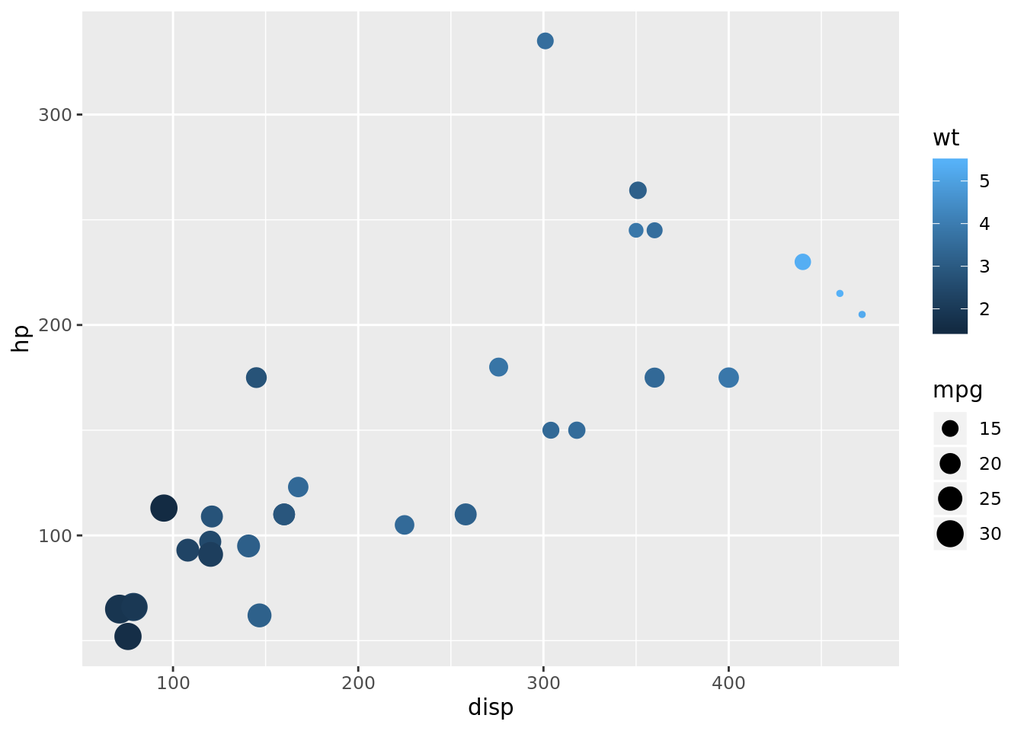

```r
# create a ggplot plot
library(ggplot2)
plot <-
  ggplot(data = mtcars,
         aes(
           x = disp,
           y = hp,
           color = wt,
           size = mpg
         )) +
  geom_point()

plot
```

```r
# create an HTML fragment that contains a ggplot as ab embedded plot
plot_html <-
  add_ggplot(
    plot_object = plot,
    height = 5,
    width = 7
  )


# include plot in the email message body
email <-
  compose_email(
    body = "
    Good morning! Below are today's latest results:

    {plot_html}

    ")

preview_email(email)
```